# Graphics in R

Your Name Here

# The Data

For this homework we will be working with the data that were used in the lecture on `ggplot` from the 2011 *The Economist* article looking at the relationship between human development and perceived corruption.

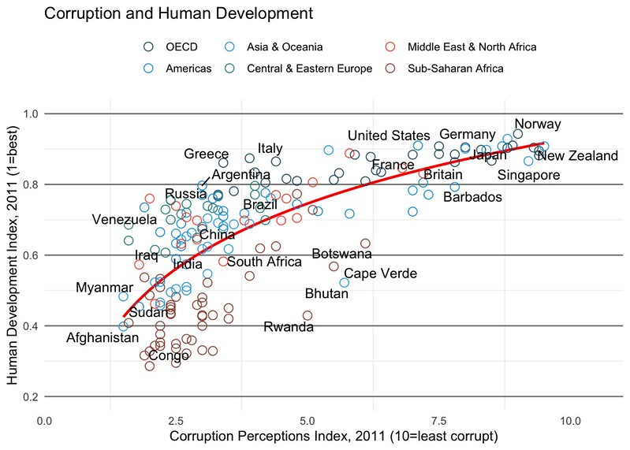

The data are located on the [class GitHub site](https://github.com/dyerlab/ENVS-Lectures) and can be accessed by the following URL, which is being presented as a CSV file.

```r
# The URL for the data on GitHub
url <- "https://raw.githubusercontent.com/dyerlab/ENVS-Lectures/master/data/EconomistData.csv"
```

Use the URL above and load the data into R and present a summary. Name this data frame `df` because some code below that I give assumes that name.

```r
## Load the data here.
library(readr)
df <- read_csv(url)
```

As it stands, we are going to need to turn the `Region` column from a raw `character` type to a `factor` data type. To to this, we can use the function `as.factor()` and assign it back to the `data.frame`.

```r
# Turn Region into factor
df$Region <- as.factor( df$Region )
summary( df )
```

```
   Country               HDI              CPI
 Length:173         Min.   :0.2860   Min.   :1.500
 Class :character   1st Qu.:0.5090   1st Qu.:2.500
 Mode  :character   Median :0.6980   Median :3.200
                    Mean   :0.6581   Mean   :4.052
                    3rd Qu.:0.7930   3rd Qu.:5.100
                    Max.   :0.9430   Max.   :9.500
                        Region
 Americas                  :31
 Asia & Oceania            :30
 Central & Eastern Europe  :18
 Middle East & North Africa:18
 OECD                      :30
 Sub-Saharan Africa        :46
```

# Univariate Data

For this section, focus on histograms and density plots. Create a historgram plot and a density plot, one for built-in graphics and the other using `ggplot`. Feel free to embellish them as you please but you **must** have properly labeled axes.

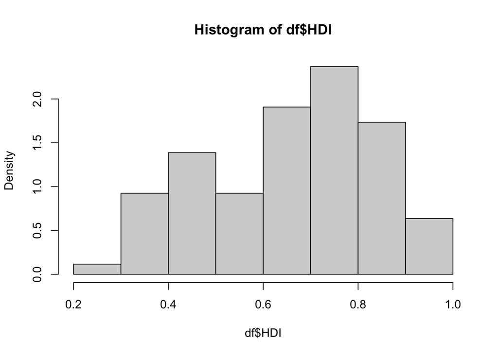

```r
# Built-in hist for HDI
hist( df$HDI, probability = TRUE  )
```

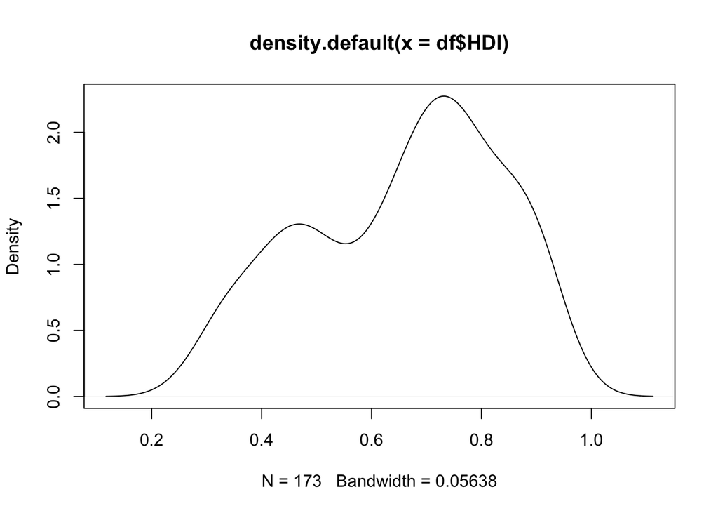

```r
# Density plot for HDI using built-in graphics
plot( density(df$HDI))
```

Now for CPI, do the same things using `ggplot` graphics.

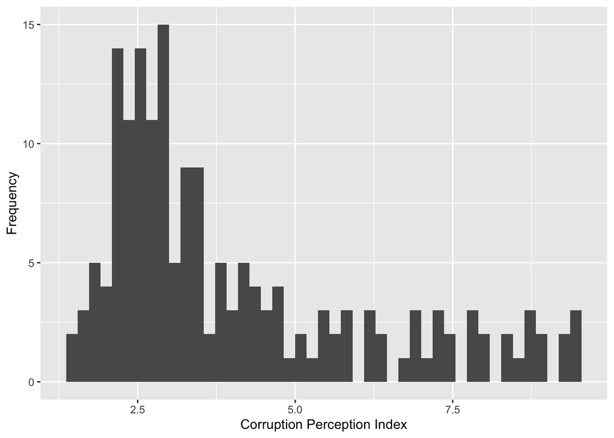

```r
# GGPlot histogram
library( ggplot2 )
ggplot( df, aes(x=CPI) ) +
  geom_histogram( bins=45) +
  xlab("Corruption Perception Index") +
  ylab("Frequency")
```

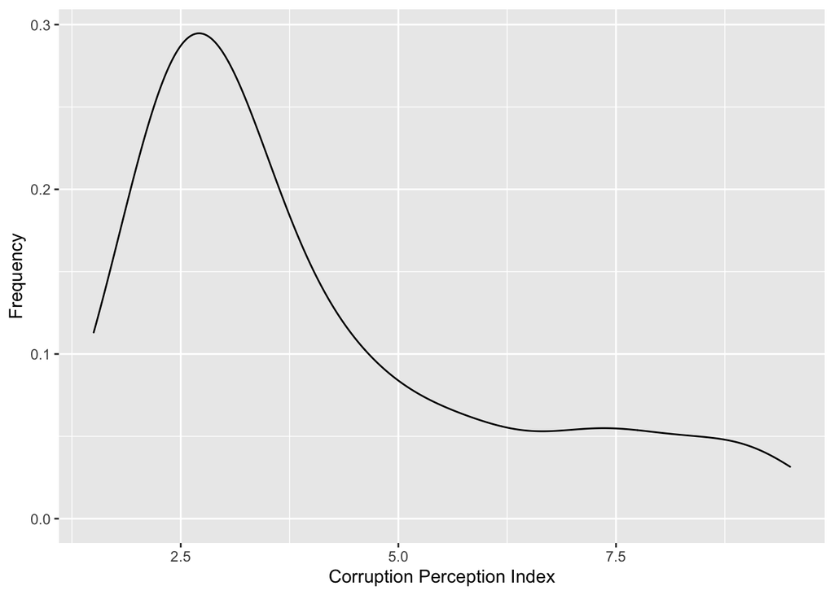

```r
# GGPlot density Plot
ggplot( df, aes(x=CPI) ) +
  geom_density() +
  xlab("Corruption Perception Index") +
  ylab("Frequency")
```

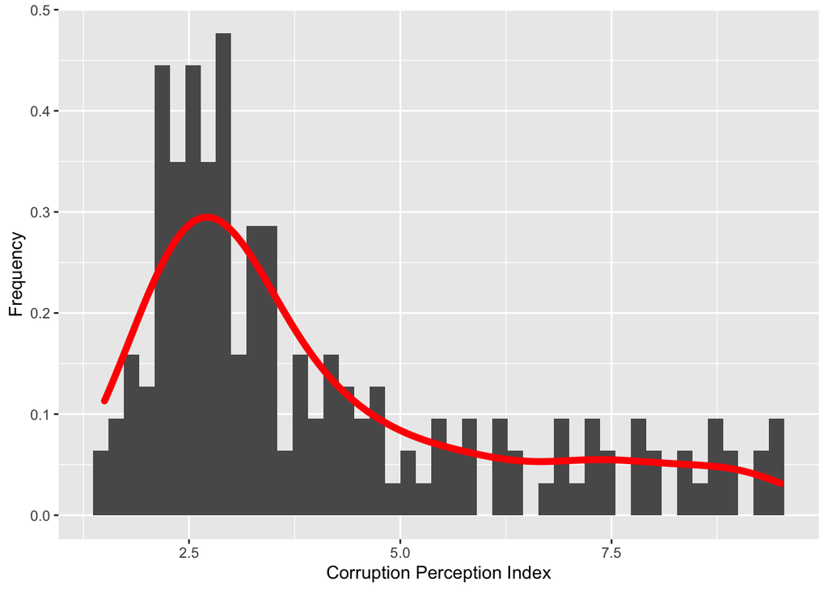

```r
# Overlay density on top of histogram using ggplot
ggplot( df, aes(x=CPI) ) +
  geom_histogram( bins=45, aes( y = ..density..)) +
  geom_density( color="red", size=2) +
  xlab("Corruption Perception Index") +
  ylab("Frequency")
```